# PCFL 2021: Week 14 wrap-up

Countdown to the playoffs: one week left!

### Last week’s games

| Away | Away points | Home | Home points | Predicted result |
| --- | --- | --- | --- | --- |
| Georgia Peanuts | 161.70 | The G.O.A.T. | 81.74 | Georgia Peanuts (+22.02) |
| KC Gophers | 57.82 | Athens Team Sasquatch | 124.72 | Athens Team Sasquatch (+23.34) |
| Middle Earth Hangry Hobbits | 115.28 | Jumpin’ Jaheims | 153.50 | Jumpin’ Jaheims (+5.46) |
| The Sophomores TSoph | 95.64 | Pigskin on the Gridiron | 140.62 | The Sophomores TSoph (+3.52) |
| Southern Sharks | 111.34 | Captain Clairvoyant | 105.02 | Captain Clairvoyant (+9.06) |

Last week’s game of the week was The Sophomores vs. Pigskin on the Gridiron, and Richard came through with the upset in a big way. While still the league leaders, Erin and Trav have now lost two in a row as the playoff run looms.

Our other upset of the week was the Sharks vs. Captain Clairvoyant. Brian was already popping the victory champagne, but a late COVID scratch and a big week from James Conner gave Sarah the victory.

#### Best performing players

Here’s last week’s **10 best performing players.**

| Player | Points | Team |
| --- | --- | --- |
| Josh Allen | 35.22 | Athens Team Sasquatch |
| Dalvin Cook | 34.70 | Pigskin on the Gridiron |
| Tom Brady | 30.12 | Captain Clairvoyant |
| Aaron Rodgers | 29.64 | The Sophomores TSoph |
| Davante Adams | 29.10 | Georgia Peanuts |
| James Conner | 29.00 | Southern Sharks |
| George Kittle | 27.60 | Middle Earth Hangry Hobbits |
| Taysom Hill | 26.30 | Jumpin’ Jaheims |
| Tyler Lockett | 25.70 | Jumpin’ Jaheims |
| Justin Herbert | 24.90 | Georgia Peanuts |

Josh Allen has had an up and down last few weeks, but he came through for Robbie this week. Dalvin Cook was the top non-QB.

#### Best addition and top bench

There were 22 players added last week. Which was the **best new addition**?

| Date added | Name | Points | Team |
| --- | --- | --- | --- |
| 2021-12-10 | Jimmy Garoppolo | 20.14 | Southern Sharks |
| 2021-12-09 | Titans D/ST | 19.00 | Middle Earth Hangry Hobbits |
| 2021-12-08 | Ryan Tannehill | 16.54 | Jumpin’ Jaheims |
| 2021-12-10 | Van Jefferson | 14.80 | Georgia Peanuts |
| 2021-12-08 | D’Onta Foreman | 13.20 | Captain Clairvoyant |
| 2021-12-10 | Austin Hooper | 11.50 | Pigskin on the Gridiron |
| 2021-12-10 | Cole Beasley | 10.90 | Southern Sharks |
| 2021-12-08 | Chuba Hubbard | 9.30 | Athens Team Sasquatch |
| 2021-12-08 | Broncos D/ST | 9.00 | Georgia Peanuts |
| 2021-12-08 | Mason Crosby | 9.00 | Athens Team Sasquatch |
| 2021-12-10 | Tyler Boyd | 8.35 | Southern Sharks |
| 2021-12-08 | Saints D/ST | 8.00 | Southern Sharks |
| 2021-12-09 | Sony Michel | 7.90 | Captain Clairvoyant |
| 2021-12-11 | Ty Johnson | 7.70 | Southern Sharks |
| 2021-12-10 | Taylor Heinicke | 7.68 | Southern Sharks |
| 2021-12-08 | Chargers D/ST | 6.00 | Athens Team Sasquatch |
| 2021-12-11 | Jeff Wilson Jr. | 5.60 | Jumpin’ Jaheims |
| 2021-12-09 | DeAndre Carter | 4.60 | Middle Earth Hangry Hobbits |
| 2021-12-08 | Seahawks D/ST | 4.00 | Pigskin on the Gridiron |
| 2021-12-08 | Tyler Conklin | 3.00 | The Sophomores TSoph |
| 2021-12-12 | Godwin Igwebuike | 0.50 | Athens Team Sasquatch |
| 2021-12-12 | Jermar Jefferson | 0.00 | Georgia Peanuts |

Who won the **best scoring bench** award last week?

| Team | Points |
| --- | --- |
| Athens Team Sasquatch | 94.32 |
| KC Gophers | 80.80 |
| Pigskin on the Gridiron | 72.42 |
| Southern Sharks | 68.37 |
| Jumpin’ Jaheims | 61.44 |
| The G.O.A.T. | 52.56 |
| Georgia Peanuts | 49.32 |
| Middle Earth Hangry Hobbits | 47.98 |
| The Sophomores TSoph | 35.42 |
| Captain Clairvoyant | 16.20 |

Go Sasquatch go!

Who has the most bench points for the *season*? Here’s the current standings:

| Team name | Total bench points |
| --- | --- |
| Southern Sharks | 1049.96 |
| Athens Team Sasquatch | 1029.17 |
| Middle Earth Hangry Hobbits | 991.79 |
| Pigskin on the Gridiron | 966.22 |
| The Sophomores TSoph | 931.00 |
| Jumpin’ Jaheims | 839.60 |
| KC Gophers | 833.82 |
| Captain Clairvoyant | 760.69 |
| Georgia Peanuts | 740.47 |
| The G.O.A.T. | 711.34 |

The Sharks’ lead is down to just 20! We’ll have to see if Robbie can catch them.

### League standings and season stats

Here’s a look at the current standings.

| Team | Division | W | L | Points scored | Points allowed | Points rank | Playoff rank |
| --- | --- | --- | --- | --- | --- | --- | --- |
| The Sophomores TSoph | Hot Dish | 10 | 4 | 1624.42 | 1535.88 | 3 | 1 |
| Athens Team Sasquatch | Grits | 9 | 5 | 1646.37 | 1535.27 | 1 | 2 |
| Pigskin on the Gridiron | Grits | 9 | 5 | 1629.71 | 1452.84 | 2 | 3 |
| Captain Clairvoyant | Grits | 9 | 5 | 1599.46 | 1443.17 | 4 | 4 |
| Georgia Peanuts | Hot Dish | 9 | 5 | 1564.52 | 1406.54 | 5 | 5 |
| Jumpin’ Jaheims | Grits | 8 | 6 | 1534.01 | 1555.13 | 8 | 6 |
| Middle Earth Hangry Hobbits | Hot Dish | 6 | 8 | 1559.98 | 1568.07 | 6 | 7 |
| Southern Sharks | Hot Dish | 5 | 9 | 1554.14 | 1609.35 | 7 | 8 |
| The G.O.A.T. | Grits | 3 | 11 | 1284.56 | 1568.65 | 9 | 9 |
| KC Gophers | Hot Dish | 2 | 12 | 1233.18 | 1555.45 | 10 | 10 |

Here’s our current awards leaders from these standings:

- Yellow shirt (most points): Team Sasquatch *new*
- Tough luck (points rank - playoff rank): No clear leader here this week–several teams one rank lower than their points would suggest.
- Lucky ducks (playoff rank - points rank): The Sophomores and Jumpin’ Jaheims *new*–third and eighth in points, but first and sixth in the rankings.

Here’s a list of the **top five scoring performances** so far this season.

| Team | Week | Points scored | Result |
| --- | --- | --- | --- |
| Georgia Peanuts | 14 | 161.70 | W |
| Georgia Peanuts | 5 | 158.97 | W |
| The Sophomores TSoph | 4 | 158.62 | W |
| Middle Earth Hangry Hobbits | 13 | 155.27 | W |
| Jumpin’ Jaheims | 14 | 153.50 | W |

With bye weeks wrapping up and rosters getting set, we’re starting to see new high scores get added to this list.

### Here’s a look at the **points trendline** for each team.

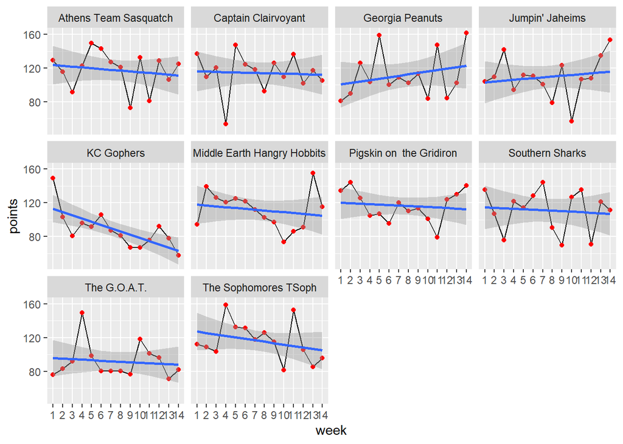

Here’s the points trend for *all* teams by week

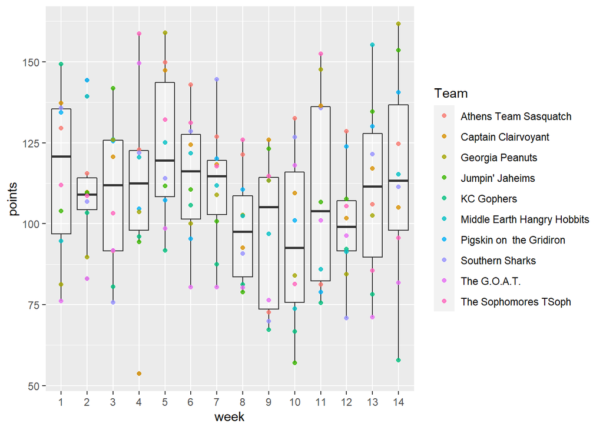

### The playoff picture!

Usually by this point things are pretty settled. And in a way they are. ESPN gives The Sophomores, Team Sasquatch, and Pigskin on the Gridiron a >98% chance of making the playoffs.

Robbie and Richard can both make the playoffs with wins this week against Scott and Sarah respectively. But an upset in one or both could leave them on the outside looking in.

It really comes down to the matchup between Brian and me for that last spot. The winner is in, and the loser very possibly out (though that would depend on Robbie and Richard).

Very exciting!

### Next week’s preview

| Away team | Last 3 wks avg (away) | Home team | Last 3 wks avg (home) | Line |
| --- | --- | --- | --- | --- |
| The G.O.A.T. | 83.05 | KC Gophers | 76.03 | The G.O.A.T. (+7.02) |
| Athens Team Sasquatch | 119.79 | Middle Earth Hangry Hobbits | 120.63 | Middle Earth Hangry Hobbits (+0.84) |
| Jumpin’ Jaheims | 131.92 | The Sophomores TSoph | 95.49 | Jumpin’ Jaheims (+36.43) |
| Pigskin on the Gridiron | 131.50 | Southern Sharks | 101.23 | Pigskin on the Gridiron (+30.27) |
| Captain Clairvoyant | 107.96 | Georgia Peanuts | 116.20 | Georgia Peanuts (+8.24) |

This week’s game of the week is the Peanuts vs. Captain Clairvoyant, as the playoffs are on the line. I’m slightly favored based on the last few weeks, but we all know how fantasy can go. There are several other meaningful matchups. At the other end, The GOAT vs. Gophers is a preview of the consolation round next week and the upcoming battle for the Toilet Trophy.

Good luck, y’all!